# Case study 2

Tran Thanh Hoa

2025-11-22

# **1. Introduction**

*Bellabeat is a high-tech company that manufactures health-focused smart products.They offer different smart devices that collect data on activity, sleep, stress, and reproductive health to empower women with knowledge about their own health and habits.*

*The main focus of this case is to analyze smart devices fitness data and determine how it could help unlock new growth opportunities for Bellabeat. We will focus on one of Bellabeat’s products: Bellabeat app.*

*The Bellabeat app provides users with health data related to their activity, sleep, stress, menstrual cycle, and mindfulness habits. This data can help users better understand their current habits and make healthy decisions. The Bellabeat app connects to their line of smart wellness product.*

# **2. Ask Phase**

## 2.1 Buiness task

Identify trends in how consumers use non-Bellabeat smart devices to apply insights into Bellabeat’s marketing strategy.

## 2.2 Stakeholders

- *UrškaSršen:* Bellabeat’s co-founder and Chief Creative Officer.
- *Sando Mur:* Mathematician and Bellabeat’s co-founder; key member of the Bellabeat executive team.
- *Bellabeat marketing analytics team:* A team of data analysts responsible for collecting, analyzing, and repo ing data that helps guide Bellabeat’s marketing strategy.

## 2.3 Products

- *Bellabeat app*: The Bellabeat app provides users with health data related to their activity, sleep, stress, menstrual cycle, and mindfulness habits. This data can help user better understand their current habits and make healthy decisions. The Bellabeat app connects to their line of smart wellness products.
- *Bellabeat’s classic wellness tracker*: can be worn as a wellness watch,bracelet, necklace, or clip. The wellness trackers connect to the Bellabeat app to track activity,sleep and stress to provide you with insights into your daily wellness.

# **3. Prepare Phase**

## 3.1 Dataset used

The data source used for our case study is [FitBit Fitness Tracker Data](https://www.kaggle.com/datasets/arashnic/fitbit/code?datasetId=1041311&sortBy=voteCount). This data set is stored in Kaggle and was made available through Mobius.

## 3.3 Data Credibility and Integrity

# **4. Process Phase**

*I will focus my analysis in R due to the accessibility, amount of data and to be able to create data visualization to share my results with stakeholders.*

## 4.1 Installing packages and opening libraries

We will use the following packages for our analysis:

- tidyverse
- lubridate
- ggplot2
- skimr
- Janitor
- knitr

```r
library(tidyverse)
library(ggplot2)
library(lubridate)
library(skimr)
library(janitor)
library(knitr)
library(ggpubr)
```

## 4.2 Importing datasets

Knowing the data sets we have, we will upload the data sets that will help us answer our business task. On our analysis we will focus on the following data sets:

- `dailyActivity_merged`
- `sleepDay_merged`
- `dailySteps_merged`

```r
daily_activity <- read.csv('C:/Case Study 2/Fitabase Data 4.12.16-5.12.16/dailyActivity_merged.csv')

daily_sleep <- read.csv('C:/Case Study 2/Fitabase Data 4.12.16-5.12.16/sleepDay_merged.csv')

daily_steps <- read.csv('C:/Case Study 2/Fitabase Data 4.12.16-5.12.16/dailySteps_merged.csv')
```

## 4.3 Preview our datasets

we will preview our selected data frames and check the summary of each column

```r
head(daily_activity)
```

```
          Id ActivityDate TotalSteps TotalDistance TrackerDistance
1 1503960366    4/12/2016      13162          8.50            8.50
2 1503960366    4/13/2016      10735          6.97            6.97
3 1503960366    4/14/2016      10460          6.74            6.74
4 1503960366    4/15/2016       9762          6.28            6.28
5 1503960366    4/16/2016      12669          8.16            8.16
6 1503960366    4/17/2016       9705          6.48            6.48
  LoggedActivitiesDistance VeryActiveDistance ModeratelyActiveDistance
1                        0               1.88                     0.55
2                        0               1.57                     0.69
3                        0               2.44                     0.40
4                        0               2.14                     1.26
5                        0               2.71                     0.41
6                        0               3.19                     0.78
  LightActiveDistance SedentaryActiveDistance VeryActiveMinutes
1                6.06                       0                25
2                4.71                       0                21
3                3.91                       0                30
4                2.83                       0                29
5                5.04                       0                36
6                2.51                       0                38
  FairlyActiveMinutes LightlyActiveMinutes SedentaryMinutes Calories
1                  13                  328              728     1985
2                  19                  217              776     1797
3                  11                  181             1218     1776
4                  34                  209              726     1745
5                  10                  221              773     1863
6                  20                  164              539     1728
```

```r
str(daily_activity)
```

```
'data.frame':   940 obs. of  15 variables:
 $ Id                      : num  1.5e+09 1.5e+09 1.5e+09 1.5e+09 1.5e+09 ...
 $ ActivityDate            : chr  "4/12/2016" "4/13/2016" "4/14/2016" "4/15/2016" ...
 $ TotalSteps              : int  13162 10735 10460 9762 12669 9705 13019 15506 10544 9819 ...
 $ TotalDistance           : num  8.5 6.97 6.74 6.28 8.16 ...
 $ TrackerDistance         : num  8.5 6.97 6.74 6.28 8.16 ...
 $ LoggedActivitiesDistance: num  0 0 0 0 0 0 0 0 0 0 ...
 $ VeryActiveDistance      : num  1.88 1.57 2.44 2.14 2.71 ...
 $ ModeratelyActiveDistance: num  0.55 0.69 0.4 1.26 0.41 ...
 $ LightActiveDistance     : num  6.06 4.71 3.91 2.83 5.04 ...
 $ SedentaryActiveDistance : num  0 0 0 0 0 0 0 0 0 0 ...
 $ VeryActiveMinutes       : int  25 21 30 29 36 38 42 50 28 19 ...
 $ FairlyActiveMinutes     : int  13 19 11 34 10 20 16 31 12 8 ...
 $ LightlyActiveMinutes    : int  328 217 181 209 221 164 233 264 205 211 ...
 $ SedentaryMinutes        : int  728 776 1218 726 773 539 1149 775 818 838 ...
 $ Calories                : int  1985 1797 1776 1745 1863 1728 1921 2035 1786 1775 ...
```

```r
head(daily_sleep)
```

```
          Id              SleepDay TotalSleepRecords TotalMinutesAsleep
1 1503960366 4/12/2016 12:00:00 AM                 1                327
2 1503960366 4/13/2016 12:00:00 AM                 2                384
3 1503960366 4/15/2016 12:00:00 AM                 1                412
4 1503960366 4/16/2016 12:00:00 AM                 2                340
5 1503960366 4/17/2016 12:00:00 AM                 1                700
6 1503960366 4/19/2016 12:00:00 AM                 1                304
  TotalTimeInBed
1            346
2            407
3            442
4            367
5            712
6            320
```

```r
str(daily_sleep)
```

```
'data.frame':   413 obs. of  5 variables:
 $ Id                : num  1.5e+09 1.5e+09 1.5e+09 1.5e+09 1.5e+09 ...
 $ SleepDay          : chr  "4/12/2016 12:00:00 AM" "4/13/2016 12:00:00 AM" "4/15/2016 12:00:00 AM" "4/16/2016 12:00:00 AM" ...
 $ TotalSleepRecords : int  1 2 1 2 1 1 1 1 1 1 ...
 $ TotalMinutesAsleep: int  327 384 412 340 700 304 360 325 361 430 ...
 $ TotalTimeInBed    : int  346 407 442 367 712 320 377 364 384 449 ...
```

```r
head(daily_steps)
```

```
          Id ActivityDay StepTotal
1 1503960366   4/12/2016     13162
2 1503960366   4/13/2016     10735
3 1503960366   4/14/2016     10460
4 1503960366   4/15/2016      9762
5 1503960366   4/16/2016     12669
6 1503960366   4/17/2016      9705
```

```r
str(daily_steps)
```

```
'data.frame':   940 obs. of  3 variables:
 $ Id         : num  1.5e+09 1.5e+09 1.5e+09 1.5e+09 1.5e+09 ...
 $ ActivityDay: chr  "4/12/2016" "4/13/2016" "4/14/2016" "4/15/2016" ...
 $ StepTotal  : int  13162 10735 10460 9762 12669 9705 13019 15506 10544 9819 ...
```

## 4.4 Cleaning and formatting

Now that we got to know more about our data structures we will process them to look for any errors and inconsistencies.

### 4.4.1 Veryfying number of users

Before we continue with our cleaning we want to make sure how many unique users are per data frame. Even though 30 is the minimal sample size we will still keep the sleep data set for practice only.

```r
# Check user on daily_activity data frame
n_unique(daily_activity$Id)
```

```
[1] 33
```

```r
# Check user on daily_sleep data frame
n_unique(daily_sleep$Id)
```

```
[1] 24
```

```r
# Check user on daily_steps data frame
n_unique(daily_steps$Id)
```

```
[1] 33
```

In the daily_sleep data frame, there maybe user who do not use a wellness tracker while sleeping.

### 4.4.2 Duplicates

We will now look for any duplicates:

```r
sum(duplicated(daily_activity))
```

```
[1] 0
```

```r
sum(duplicated(daily_sleep))
```

```
[1] 3
```

```r
sum(duplicated(daily_steps))
```

```
[1] 0
```

### 4.4.3 Remove duplicates and N/A

```r
daily_activity <- daily_activity %>%
  distinct() %>%
  drop_na()

daily_sleep <- daily_sleep %>%
  distinct() %>%
  drop_na()

daily_steps <- daily_steps %>%
  distinct() %>%
  drop_na()
```

```r
sum(duplicated(daily_sleep))
```

```
[1] 0
```

We will verify that duplicates have been removed.

### 4.4.4 Clean and rename columns

We want to ensure that column names are using right syntax and same format in all data sets since we will merge them later on. We are changing the format of all columns to lower case.

- First, we can check column names of all data sets

```r
# Changing format of all columns to lower case and create under scored in daily_activity data frames
daily_activity <- clean_names(daily_activity)


# Changing format of all columns to lower case and in daily_sleep data frames
daily_sleep <- clean_names(daily_sleep)

# Changing format of all columns to lower case and in daily_steps data frames
daily_steps <- clean_names(daily_steps)
```

### 4.4.5 Consistency of date and time columns

So, we will focus on cleaning date-time format for `daily_activity` and `daily_sleep` data frames since we will merge both data frames. Since We can disregard the time on `daily_sleep` data frame we are using `as-date` instead `as_datetime`.

```r
daily_activity <- daily_activity %>%
  rename(date = activity_date) %>%
  mutate(date = as_date(date,format = "%m/%d/%Y"))

daily_sleep <- daily_sleep %>%
  rename(date = sleep_day) %>%
  mutate(date = as_date(date,format = "%m/%d/%Y %I:%M:%S %p", tz = Sys.timezone()))
```

We will check our cleaned datasets.

```r
head(daily_activity)
```

```
          id       date total_steps total_distance tracker_distance
1 1503960366 2016-04-12       13162           8.50             8.50
2 1503960366 2016-04-13       10735           6.97             6.97
3 1503960366 2016-04-14       10460           6.74             6.74
4 1503960366 2016-04-15        9762           6.28             6.28
5 1503960366 2016-04-16       12669           8.16             8.16
6 1503960366 2016-04-17        9705           6.48             6.48
  logged_activities_distance very_active_distance moderately_active_distance
1                          0                 1.88                       0.55
2                          0                 1.57                       0.69
3                          0                 2.44                       0.40
4                          0                 2.14                       1.26
5                          0                 2.71                       0.41
6                          0                 3.19                       0.78
  light_active_distance sedentary_active_distance very_active_minutes
1                  6.06                         0                  25
2                  4.71                         0                  21
3                  3.91                         0                  30
4                  2.83                         0                  29
5                  5.04                         0                  36
6                  2.51                         0                  38
  fairly_active_minutes lightly_active_minutes sedentary_minutes calories
1                    13                    328               728     1985
2                    19                    217               776     1797
3                    11                    181              1218     1776
4                    34                    209               726     1745
5                    10                    221               773     1863
6                    20                    164               539     1728
```

```r
head(daily_sleep)
```

```
          id       date total_sleep_records total_minutes_asleep
1 1503960366 2016-04-12                   1                  327
2 1503960366 2016-04-13                   2                  384
3 1503960366 2016-04-15                   1                  412
4 1503960366 2016-04-16                   2                  340
5 1503960366 2016-04-17                   1                  700
6 1503960366 2016-04-19                   1                  304
  total_time_in_bed
1               346
2               407
3               442
4               367
5               712
6               320
```

## 4.5 Merging Datasets

We will merge `daily_activity` and `daily_sleep` to see any correlation between variables by using `id` and `date` as their primary keys.

```r
daily_activity_sleep <- merge(daily_activity, daily_sleep, by = c('id','date'))

glimpse(daily_activity_sleep)
```

```
Rows: 410
Columns: 18
$ id                         <dbl> 1503960366, 1503960366, 1503960366, 1503960…
$ date                       <date> 2016-04-12, 2016-04-13, 2016-04-15, 2016-0…
$ total_steps                <int> 13162, 10735, 9762, 12669, 9705, 15506, 105…
$ total_distance             <dbl> 8.50, 6.97, 6.28, 8.16, 6.48, 9.88, 6.68, 6…
$ tracker_distance           <dbl> 8.50, 6.97, 6.28, 8.16, 6.48, 9.88, 6.68, 6…
$ logged_activities_distance <dbl> 0, 0, 0, 0, 0, 0, 0, 0, 0, 0, 0, 0, 0, 0, 0…
$ very_active_distance       <dbl> 1.88, 1.57, 2.14, 2.71, 3.19, 3.53, 1.96, 1…
$ moderately_active_distance <dbl> 0.55, 0.69, 1.26, 0.41, 0.78, 1.32, 0.48, 0…
$ light_active_distance      <dbl> 6.06, 4.71, 2.83, 5.04, 2.51, 5.03, 4.24, 4…
$ sedentary_active_distance  <dbl> 0, 0, 0, 0, 0, 0, 0, 0, 0, 0, 0, 0, 0, 0, 0…
$ very_active_minutes        <int> 25, 21, 29, 36, 38, 50, 28, 19, 41, 39, 73,…
$ fairly_active_minutes      <int> 13, 19, 34, 10, 20, 31, 12, 8, 21, 5, 14, 2…
$ lightly_active_minutes     <int> 328, 217, 209, 221, 164, 264, 205, 211, 262…
$ sedentary_minutes          <int> 728, 776, 726, 773, 539, 775, 818, 838, 732…
$ calories                   <int> 1985, 1797, 1745, 1863, 1728, 2035, 1786, 1…
$ total_sleep_records        <int> 1, 2, 1, 2, 1, 1, 1, 1, 1, 1, 1, 1, 1, 1, 1…
$ total_minutes_asleep       <int> 327, 384, 412, 340, 700, 304, 360, 325, 361…
$ total_time_in_bed          <int> 346, 407, 442, 367, 712, 320, 377, 364, 384…
```

# **5. Analyze Phase and Share Phase**

## 5.1 Type of user per activity level

Since we don’t have any demographic variables from our sample we want to determine the type of users with the data we have. We can classify the users by activity considering the daily amount of steps. We can categorize users as follows:

- Sedentary : Less than 5000 steps a day.
- Lightly active: Between 5000 and 7499 steps a day.
- Fairly active: Between 7500 and 9999 steps a day.
- Very active: More 10000 steps a day.

```r
daily_average_activity_users <- daily_activity_sleep %>%
  group_by(id) %>%
  summarise(Average_sleep_minutes = mean(total_minutes_asleep),
            Average_calorie_consumption = mean(calories),
            Average_steps = mean(total_steps),
            )

head(daily_average_activity_users)
```

```
# A tibble: 6 × 4
          id Average_sleep_minutes Average_calorie_consumption Average_steps
       <dbl>                 <dbl>                       <dbl>         <dbl>
1 1503960366                  360.                       1872.        12406.
2 1644430081                  294                        2978.         7968.
3 1844505072                  652                        1676.         3477
4 1927972279                  417                        2316.         1490
5 2026352035                  506.                       1541.         5619.
6 2320127002                   61                        1804          5079
```

- Type of user per activity level

```r
user_types <- daily_average_activity_users %>%
  mutate(user_types = case_when(
                              Average_steps < 5000 ~ "Sedentary",
                              Average_steps >= 5000 & Average_steps <= 7499 ~ "Lightly active",
                              Average_steps >= 7500 & Average_steps <= 9999 ~ "Fairly active",
                              Average_steps >= 10000 ~ "Very active"))
head(user_types)
```

```
# A tibble: 6 × 5
        id Average_sleep_minutes Average_calorie_cons…¹ Average_steps user_types
     <dbl>                 <dbl>                  <dbl>         <dbl> <chr>
1   1.50e9                  360.                  1872.        12406. Very acti…
2   1.64e9                  294                   2978.         7968. Fairly ac…
3   1.84e9                  652                   1676.         3477  Sedentary
4   1.93e9                  417                   2316.         1490  Sedentary
5   2.03e9                  506.                  1541.         5619. Lightly a…
6   2.32e9                   61                   1804          5079  Lightly a…
# ℹ abbreviated name: ¹Average_calorie_consumption
```

```r
user_types_percent <- user_types %>%
  group_by(user_types) %>%
  summarise(total = n()) %>%
  mutate(totals = sum(total)) %>%
  group_by(user_types) %>%
  summarise(total_percent = total / totals) %>%
  mutate(label = scales::percent(total_percent))
head(user_types_percent)
```

```
# A tibble: 4 × 3
  user_types     total_percent label
  <chr>                  <dbl> <chr>
1 Fairly active          0.375 38%
2 Lightly active         0.208 21%
3 Sedentary              0.208 21%
4 Very active            0.208 21%
```

Now, we have a new column with the user types we will create a data frame with the percentage of each user types to better visualize them on a graph.

- First, we need to arrange the `user_types` in order.

```r
user_types_percent$user_types = factor(user_types_percent$user_types, levels = c("Sedentary", "Lightly active", "Fairly active", "Very active"))
```

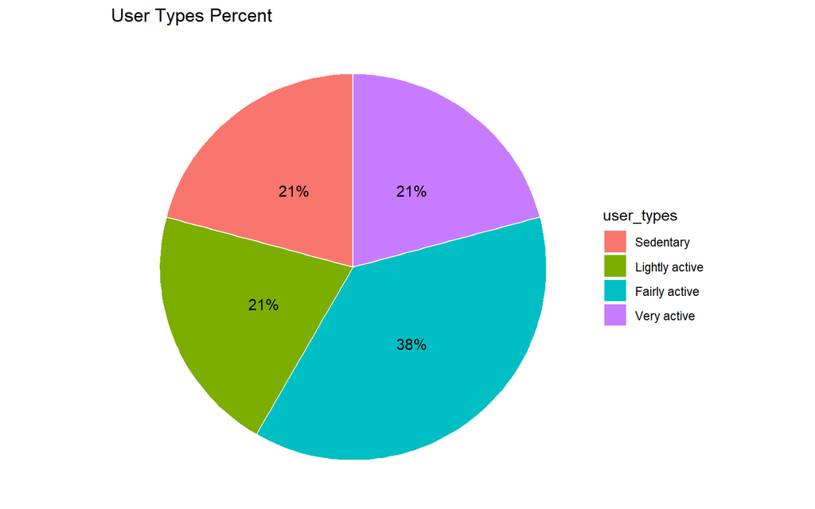

```r
user_types_percent  %>%
  ggplot(mapping = aes(x = "" ,y = total_percent, fill = user_types)) +
  geom_col(width = 1, color = "white") +
  coord_polar(theta = "y") +
  geom_text(aes(label = label), position = position_stack(vjust = 0.5)) +
  theme_void() +
  ggtitle("User Types Percent")
```

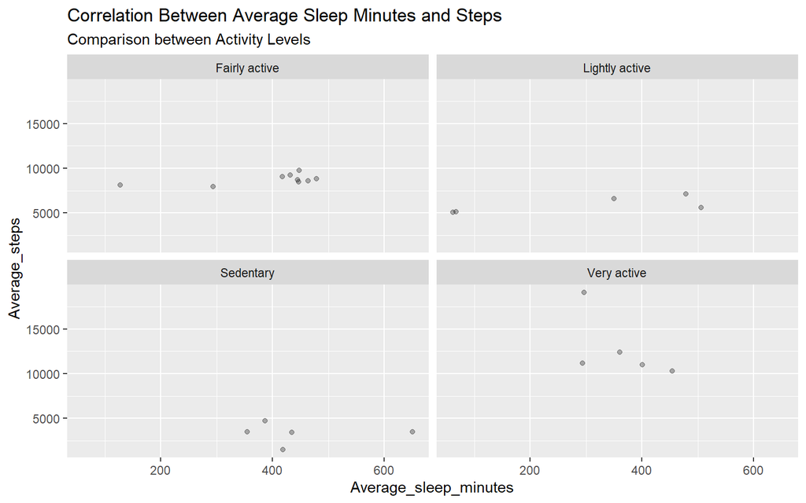

```r
user_types %>%
  ggplot(aes(x = Average_sleep_minutes, y = Average_steps,colours = user_types)) + geom_point(alpha = 0.3, position = position_jitter()) + facet_wrap(~ user_types) + labs(title = "Correlation Between Average Sleep Minutes and Steps", subtitle = "Comparison between Activity Levels")
```

*At different levels of user activity, higher-activity user groups (`Fairly active` and `Very active`) show significantly higher daily step counts, while sleep duration does not show a clear relationship with step counts between user groups.However, the dataset contains relatively few users.*

- Next, we want to know exactly now what days of the week are the users more active and also what days of the week users sleep more.

## 5.2 Steps and minutes asleep per weekday

We will check whether users meet the recommended step and sleep time thresholds.

- Create a weekday variable from the date column and calculate the average number of steps and minutes of a sleep for each day of week

```r
daily_activity_sleep_of_week <- daily_activity_sleep %>%
  mutate(type = case_when(total_steps < 5000 ~ "Sedantary",
                                total_steps >= 5000 & total_steps <= 7499 ~ "Lightly active",
                                total_steps >= 7500 & total_steps <= 9999 ~ "Fairyly active",
                              total_steps >= 10000  ~ "Very active"),
    day_of_week = factor(weekdays(date),levels = c("Monday","Tuesday","Wednesday","Thursday","Friday","Saturday","Sunday"),ordered = T))
```

```r
table(daily_activity_sleep_of_week$type)
```

```
Fairyly active Lightly active      Sedantary    Very active
            77             72             96            165
```

```r
table(daily_activity_sleep_of_week$day_of_week)
```

```
   Monday   Tuesday Wednesday  Thursday    Friday  Saturday    Sunday
       46        65        66        64        57        57        55
```

- Summarize and calculating the average steps and minutes sleeps.

```r
Average_activity_of_week <- daily_activity_sleep_of_week %>%
  group_by(day_of_week) %>%
  summarise(avg_daily_steps = mean(total_steps),
            avg_daily_sleep = mean(total_minutes_asleep))

head(Average_activity_of_week)
```

```
# A tibble: 6 × 3
  day_of_week avg_daily_steps avg_daily_sleep
  <ord>                 <dbl>           <dbl>
1 Monday                9273.            420.
2 Tuesday               9183.            405.
3 Wednesday             8023.            435.
4 Thursday              8184.            401.
5 Friday                7901.            405.
6 Saturday              9871.            419.
```

So we will visually go through the activities (Minutes sleep and steps daily) of these users over a week.

- [How Much Sleep Do You Really Need?](https://www.thensf.org/how-many-hours-of-sleep-do-you-really-need/) : “Between the ages of 18 and 64, adults should aim for **seven to nine hours** of nightly sleep”.
- [How many steps/day are enough? for adults](https://pubmed.ncbi.nlm.nih.gov/21798015/): “A direct estimate of minimal amounts of MVPA accumulated in the course of objectively monitored free-living behaviour is **7,000-8,000** steps/day”.

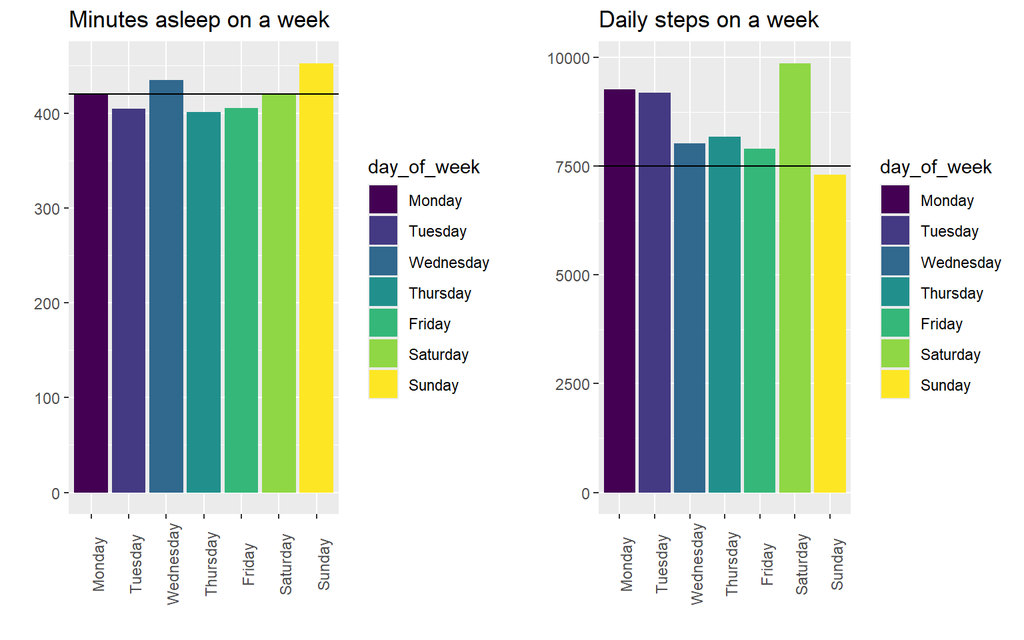

```r
ggarrange(
  ggplot(Average_activity_of_week) + geom_col(mapping = aes(x = day_of_week, y = avg_daily_sleep,fill = day_of_week)) + geom_hline(yintercept = 420) + labs(title = "Minutes asleep on a week", x = " ", y = " ") + theme(axis.text.x = element_text(angle = 90)),

  ggplot(Average_activity_of_week) + geom_col(mapping = aes(x = day_of_week, y = avg_daily_steps,fill = day_of_week)) + geom_hline(yintercept = 7500) + labs(title = "Daily steps on a week", x = " ", y = " ") + theme(axis.text.x = element_text(angle = 90))
)
```

In the graphs above we can determine the following:

- User have sleep close the recommended amount of minutes/hours - 7 to 9 hours.
- Users walk daily the recommended amount of steps of 7500 except Sunday.
- On Saturdays, they don’t go to work, users’ daily steps are the highest, during activities like walking outdoors. So on Sundays, they spend time resting and sleeping to prepare for the new work week.

## 5.3 Correlation

In the chart **`"Correlation Between Average Sleep Minutes and Steps Activity Levels"`** we can see that there is no relationship in sleep habits between people who are less active and those who are more active. Therefore, to gain a clearer view, we will proceed to build a more big-picture.

We will now determine if there is any correlation between different variables:

- Daily steps and daily sleep.
- Daily steps and calories.

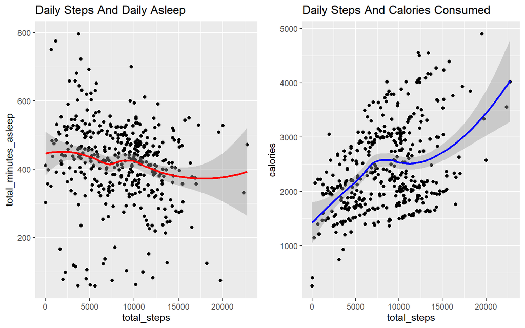

```r
ggarrange(
    ggplot(daily_activity_sleep,aes(x = total_steps, y = total_minutes_asleep)) + geom_point() + geom_smooth(color = "red") + labs(title = "Daily Steps And Daily Asleep"),
    ggplot(daily_activity_sleep,aes(x = total_steps, y = calories)) + geom_point() + geom_smooth(color = "blue") + labs(title = "Daily Steps And Calories Consumed")
)
```

**Comments:**

- In the Paragraph 1 `Daily Steps And Daily Asleep`, there is no *correlation* between daily activity based on the number of steps and the number of minutes a user sleeps each day.
- On the contrary, we can see a positive correlation between the number of steps and calories consume. We can conclude that taking more steps help consumed more calories.

# 6. Conclusion( Act Phase )

Datasets used have a small sample and can be biased since we didn’t have any demographic details of users. Knowing that our main target are young and adult women I would encourage to continue finding trends to be able to create a marketing focused on them.

**Recommendations**

**Strategy A:** *“Wellness that blends into your life”* .

**Proposal:** We will divide the regime into four types of users based on their daily physical activity, from which suitable strategies for each individual will be provided, and notify them daily with a single note about Everyday Movement Lifestyle (Key Marketing Messages).

1. Ease Mode/ Gentle Rhythm ( < 5,000 steps): We focus on promoting long-term wellness by encouraging gentle daily movement, offering mindful activity reminders, and integrating calming meditation and relaxation features. The messaging stays warm and supportive, avoiding any high-intensity fitness wording.
2. Daily Flow / Active Ease ( Between >= 5000 and <= 7499 steps ): Enhance their daily habits with small, achievable goals and cleverly designed challenges, making it easier to meet scientifically recommended steps and providing added motivation.
3. Balanced Motion / Everyday Energy ( Between >= 7500 and <= 9999 steps ): Provide daily reminders and set goals so they can achieve the 10,000-steps.
4. Peak Vitality / Dynamic Performance ( > 10000 steps): Create additional programs and metrics to help them monitor indicators (Recovery Metrics, General Wellness Metrics, Stress level, …)

**Rationale:** Activity segmentation allows us to deliver tailored goals, reminders, and insights. Users engage longer with personalized guidance, which directly improves retention and daily active usage.

**Strategy B:** *“Train smarter by listening to your night.”*.

**Proposal:** Our sleep-adjusted workout recommendation analyzes sleep duration, sleep quality, and recovery metrics (HRV, resting heart rate) to determine your body’s readiness for physical load and for training and daily walking routines.

**Rationale:** When sleep and training work together, your performance improves naturally:

- More progress
- Fewer injuries
- A healthier rhythm for your everyday life,…

=> The most attractive thing is the feeling of being understood + being supported + living healthily with ease.